# MARVEL

Sean Wen

# Installation

MARVEL is available on CRAN and also on Github. To access features in beta-testing phase, please install the package from Github: https://github.com/wenweixiong/MARVEL.

# Introduction

This tutorial demonstrates the application of MARVEL for integrated gene and splicing analysis of single-cell RNA-sequencing data. The dataset used to demonstrate the utility of MARVEL here includes induced pluripotent stem cells (iPSCs) and iPSC-induced endoderm cells (Linker *et al.*, 2019). For conciseness, only a subset of the original data will be used here, and only the most salient functions will be demonstrated here. For the complete functionalities of MARVEL, please refer to https://wenweixiong.github.io/MARVEL_Plate.html and https://wenweixiong.github.io/MARVEL_Droplet.html.

# Load package

```r
# Load MARVEL package
library(MARVEL)

# Load adjunct packages for this tutorial
library(ggplot2)
library(gridExtra)
```

```r
# Load adjunct packages to support additional functionalities
library(AnnotationDbi) # GO analysis
library(clusterProfiler)
library(org.Hs.eg.db)
library(org.Mm.eg.db)
```

```r
# Load adjunct packages to support additional functionalities
library(plyr) # General data processing
library(ggrepel) # General plotting
library(parallel) # To enable multi-thread during RI PSI computation
library(textclean) # AFE, ALE detection
library(fitdistrplus) # Modality analysis: Fit beta distribution
library(FactoMineR) # PCA: Reduce dimension
library(factoextra) # PCA: Retrieve eigenvalues
library(kSamples) # Anderson-Darling (AD) statistical test
library(twosamples) # D Test Statistic (DTS) statistical test
library(stringr) # Plot GO results
```

# Input files

The input files have been saved in a MARVEL object, and will be elaborated below.

```r
# Load saved MARVEL object
marvel.demo <- readRDS(system.file("extdata/data", "marvel.demo.rds", package="MARVEL"))
class(marvel.demo)
```

```
## [1] "Marvel"
```

## Sample metadata

This is a tab-delimited file created by the user whereby the rows represent the sample (cell) IDs and columns represent the cell information such as cell type, donor ID etc.. Compulsory column is `sample.id` while all other columns are optional.

```r
SplicePheno <- marvel.demo$SplicePheno
head(SplicePheno)
```

```
##     sample.id cell.type sample.type qc.seq
## 2  ERR1562084      iPSC Single Cell   pass
## 10 ERR1562092      iPSC Single Cell   pass
## 18 ERR1562100      iPSC Single Cell   pass
## 25 ERR1562107      iPSC Single Cell   pass
## 38 ERR1562120      iPSC Single Cell   pass
## 41 ERR1562123      iPSC Single Cell   pass
```

## Splice junction counts matrix

The rows of this matrix represent the splice junction coordinates, the columns represent the sample IDs, and the values represent the splice junction counts. The first column should be named `coord.intron`.  
Here, the splice junction counts were quantified using the STAR aligner version 2.6.1d in 2-pass mode (Dobin *et al.*, 2013). An example code for one sample (ERR1562083) below. Note a separate folder `SJ` is created here to contain the splice junction count files (SJ.out.tab) generated from 1st pass mode to be used for 2nd pass mode.

```r
# STAR in 1st pass mode
STAR --runThreadN 16 \
     --genomeDir GRCh38_GENCODE_genome_STAR_indexed \
     --readFilesCommand zcat \
     --readFilesIn ERR1562083_1_val_1.fq.gz ERR1562083_2_val_2.fq.gz \
     --outFileNamePrefix SJ/ERR1562083. \
     --outSAMtype None

# STAR in 2nd pass mode
STAR --runThreadN 16 \
     --genomeDir GRCh38_GENCODE_genome_STAR_indexed \
     --readFilesCommand zcat \
     --readFilesIn ERR1562083_1_val_1.fq.gz ERR1562083_2_val_2.fq.gz \
     --outFileNamePrefix ERR1562083. \
     --sjdbFileChrStartEnd SJ/*SJ.out.tab \
     --outSAMtype BAM SortedByCoordinate \
     --outSAMattributes NH HI AS nM XS \
     --quantMode TranscriptomeSAM
```

Once the individual splice junction count files have been generated, they should be collated and read into R as follows:

```r
SpliceJunction <- marvel.demo$SpliceJunction
SpliceJunction[1:5,1:5]
```

```
##                 coord.intron ERR1562084 ERR1562092 ERR1562100 ERR1562107
## 44383 chr1:19357564:19378539        219         37        457        276
## 44387 chr1:19374456:19378539         NA         NA         NA         NA
## 71516 chr1:28236453:28237760          5         22         58         16
## 71517 chr1:28236453:28237836        193        104        265        190
## 93429 chr1:62196529:62203446          4         NA         13         NA
```

## Splicing event metadata

The rows of this metadata represent the splicing events while the columns represent the splicing event information such as the transcript ID and the corresponding gene information. Compulsory columns are `tran_id` and `gene_id`.  
The splicing events here were detected using rMATS version 4.1.0 (Shen *et al.*, 2014). For preparing splicing event nomenclatures (`tran_id`), please refer to https://wenweixiong.github.io/Splicing_Nomenclature. Example code for running rMATS as follows.  
Note that any BAM files may be specified in `--b1` and `--b2`. This is because rMATS requires these specification for statistical testing of splicing events between the two samples. But here, we will only be using the splicing events detected (fromGTF.SE.txt, fromGTF.MXE.txt, fromGTF.RI.txt, fromGTF.A5SS.txt, fromGTF.A3SS.txt), but not the statistical test results, from this step for our downstream analysis.

```r
rmats \
    --b1 path_to_BAM_sample_1.txt \
    --b2 path_to_BAM_sample_2.txt \
    --gtf gencode.v31.annotation.gtf \
    --od rMATS/ \
    --tmp rMATS/ \
    -t paired \
    --readLength 125 \
    --variable-read-length \
    --nthread 8 \
    --statoff
```

Once the individual splicing event files for SE, MXE, RI, A5S5, and A3SS have been generated, they may be read into R as follows:

```r
SpliceFeature <-marvel.demo$SpliceFeature
lapply(SpliceFeature, head)
```

```
## $SE
##                                                                           tran_id
## 9578     chr1:62196435:62196528:+@chr1:62203447:62203557:+@chr1:62206519:62207636
## 10483 chr15:24962114:24962209:+@chr15:24967029:24967152:+@chr15:24967932:24968082
## 10484 chr15:24962114:24962209:+@chr15:24967029:24967240:+@chr15:24967932:24968082
## 11921 chr17:51153576:51153662:+@chr17:51154225:51154444:+@chr17:51155651:51155780
## 15780 chr10:78037194:78037304:+@chr10:78037439:78037441:+@chr10:78040204:78040225
## 15782 chr10:78037194:78037304:+@chr10:78037965:78037982:+@chr10:78040204:78040225
##                  gene_id gene_short_name      gene_type
## 9578   ENSG00000240563.2           L1TD1 protein_coding
## 10483 ENSG00000128739.22           SNRPN protein_coding
## 10484 ENSG00000128739.22           SNRPN protein_coding
## 11921  ENSG00000239672.7            NME1 protein_coding
## 15780 ENSG00000138326.20           RPS24 protein_coding
## 15782 ENSG00000138326.20           RPS24 protein_coding
```

[output cut: 96 more lines]

## Intron count matrix

The rows of this matrix represent intron coordinates, the columns represent the sample IDs, and the values represent the total reads mapping to the intron. These values will be used to compute the percent spliced-in (PSI) values of retained introns (RI) splicing events downstream.  
Here, intron coverage was computed using Bedtools version 2.27.1 (Quinlan *et al.*, 2010). Example code for one sample (ERR1562083) below. This code computes the counts at each base of a given intron, the sum of which, will be the total counts for the given intron. It is this total counts that is represented in the matrix.  
Note for GRCh38.primary_assembly.genome_bedtools.txt, the first column consists of the chromosome name (chr1, chr2, chr3…) and the second column consists of the chromosome size or length. Additionally, the BED file RI_Coordinates.bed contains the intron coordinates from `RI_featureData.txt` generated from rMATS in the previous step.

```r
bedtools coverage \
               -g GRCh38.primary_assembly.genome_bedtools.txt \
               -split \
               -sorted \
               -a RI_Coordinates.bed \
               -b ERR1562083.Aligned.sortedByCoord.out.bam > \
                  ERR1562083.txt \
               -d
```

Once the individual splice junction count files have been generated, they should be collated and read into R as follows:

```r
IntronCounts <- marvel.demo$IntronCounts
IntronCounts[1:5,1:5]
```

```
##                coord.intron ERR1562084 ERR1562092 ERR1562100 ERR1562107
## 1233 chr2:55232873:55233362        259        141        481        175
## 2562 chr4:39458442:39458890       5466       6105      46238      20963
## 3552 chr6:34236964:34237203       2395         30       2940        547
## 3657 chr6:73519065:73519127     117305      69093     204019     123522
## 3867   chr7:5528345:5528563     231508     146758     458847     297025
```

## Gene expression matrix

The rows of this matrix represent the gene IDs, the columns represent the sample IDs, and the values represent the normalised gene expression counts (e.g., RPKM/FPKM/TPM), but not yet log2-transformed.  
Here, gene expression was quantified using RSEM version 1.2.31 (Li *et al.*, 2011). Example code for one sample (ERR1562083) as follows. Here, the values returned are in transcript per million (TPM) unit.

```r
rsem-calculate-expression --bam \
                          --paired-end \
                          -p 8 \
                          ERR1562083.Aligned.toTranscriptome.out.bam \
                          GRCh38_GENCODE_genome_RSEM_indexed/gencode.v31 \
                          ERR1562083
```

Once the individual gene expression files have been generated, they should be collated and read into R as follows:

```r
Exp <- marvel.demo$Exp
Exp[1:5,1:5]
```

```
##                 gene_id ERR1562084 ERR1562092 ERR1562100 ERR1562107
## 1007 ENSG00000067225.18   8.007924   5.993674   7.876640   7.956231
## 1248 ENSG00000073921.18   3.460743   6.365798   4.032101   7.397974
## 1309 ENSG00000075415.12   9.497652   9.838385   8.908573   9.913742
## 1317 ENSG00000075624.16  11.493971  11.368496  11.589609  11.712037
## 1392 ENSG00000077549.18   8.425887   6.874797   8.566244   8.752314
```

## Gene metadata

The rows of this metadata represent the gene IDs while the columns represent the gene information such as the abbreviated gene names and gene type. Compulsory columns are `gene_id`, `gene_short_name`, and `gene_type`. All other columns are optional.  
Here, the metadata information was parsed and retrieved from gencode.v31.annotation.gtf.

```r
GeneFeature <- marvel.demo$GeneFeature
head(GeneFeature)
```

```
##                 gene_id gene_short_name      gene_type
## 1007 ENSG00000067225.18             PKM protein_coding
## 1248 ENSG00000073921.18          PICALM protein_coding
## 1309 ENSG00000075415.12         SLC25A3 protein_coding
## 1317 ENSG00000075624.16            ACTB protein_coding
## 1392 ENSG00000077549.18           CAPZB protein_coding
## 1806 ENSG00000089009.15      AC004086.1 protein_coding
```

# Create MARVEL object

```r
marvel <- CreateMarvelObject(SpliceJunction=SpliceJunction,
                             SplicePheno=SplicePheno,
                             SpliceFeature=SpliceFeature,
                             IntronCounts=IntronCounts,
                             GeneFeature=GeneFeature,
                             Exp=Exp
                             )
```

# Compute PSI

MARVEL will compute the percent spliced-in (PSI) values for each splicing event. Only splicing event supported by splice junction reads, i.e., high-confidence splicing events, will be selected for PSI quantification. The minimum number of splice junction reads required may be specified using the `CoverageThreshold` option.

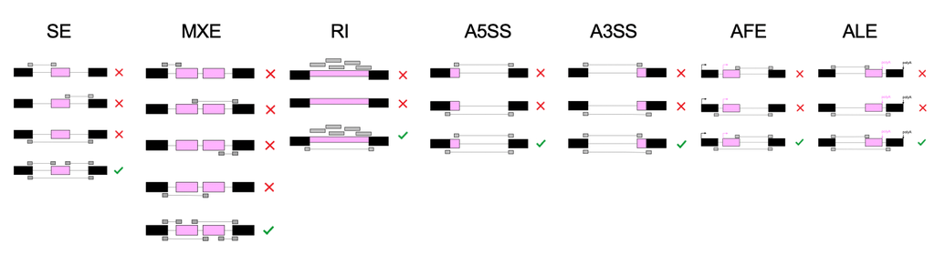

PSI is simply the proportion of reads supporting the inclusion of the alternative exon divided by the total number of reads mapping to the splicing event, which encompasses the reads supporting the inclusion and also reads supporting the exclusion of the splicing event. This fraction is in turn converted to percentage.

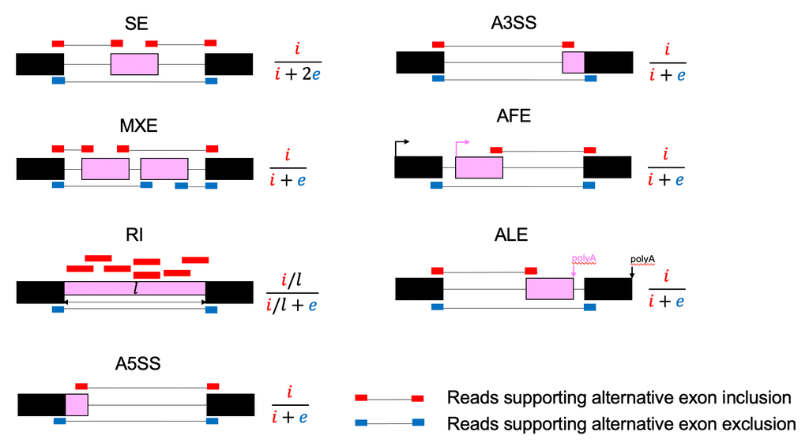

```r
# Check splicing junction data
marvel.demo <- CheckAlignment(MarvelObject=marvel.demo, level="SJ")
```

- Ensure that only MATCHED flags are reported. If any NOT MATCHED flags are reported, please double-check the input file requirements.

```r
# Validate, filter, compute SE splicing events
marvel.demo <- ComputePSI(MarvelObject=marvel.demo,
                          CoverageThreshold=10,
                          UnevenCoverageMultiplier=10,
                          EventType="SE"
                          )

# Validate, filter, compute MXE splicing events
marvel.demo <- ComputePSI(MarvelObject=marvel.demo,
                          CoverageThreshold=10,
                          UnevenCoverageMultiplier=10,
                          EventType="MXE"
                          )

# Validate, filter, compute RI splicing events
marvel.demo <- ComputePSI(MarvelObject=marvel.demo,
                          CoverageThreshold=10,
                          EventType="RI",
                          thread=4
                          )

# Validate, filter, compute A5SS splicing events
marvel.demo <- ComputePSI(MarvelObject=marvel.demo,
                          CoverageThreshold=10,
                          EventType="A5SS"
                          )

# Validate, filter, compute A3SS splicing events
marvel.demo <- ComputePSI(MarvelObject=marvel.demo,
                          CoverageThreshold=10,
                          EventType="A3SS"
                          )

# Validate, filter, compute AFE splicing events
marvel.demo <- ComputePSI(MarvelObject=marvel.demo,
                          CoverageThreshold=10,
                          EventType="AFE"
                          )

# Validate, filter, compute ALE splicing events
marvel.demo <- ComputePSI(MarvelObject=marvel.demo,
                          CoverageThreshold=10,
                          EventType="ALE"
                          )
```

The common option across all functions for computing PSI value is `CoverageThreshold`. This option indicates the minimum number of splice junction reads supporting the splicing events, above which, the PSI will be computed. PSI of splicing events below this threshold will be coded as `NA`.  
Options specific to a given splicing event are:

- `UnevenCoverageMultiplier` Specific to computing SE and MXE. Two splice junctions are used to compute to inclusion of SE and MXE. This option represent the ratio of read coverage of one splice junction over the other. The threshold specified here, above which, the PSI will be coded as `NA`.
- `thread` Specific to computing RI. Number of cores to use. This is depended on the user’s device.
- `read.length` Specific to computing RI. If the values in `df.intron.counts` represent number of reads, then this option should reflect the sequencing read length, e.g., 150 etc.. If the values in `df.intron.counts` represent total intronic coverage (here), then this option should be set to `1` (default).

# Pre-flight check

This step ensures that our data is ready for further downstream analysis, including modality assignment, differential expression analysis, dimension reduction, and functional annotation.

## Transform expression values

Gene expression values will be log2-transformed. You may skip this step if your gene expression matrix has been transformed prior to creating the MARVEL object.

```r
marvel.demo <- TransformExpValues(MarvelObject=marvel.demo,
                                  offset=1,
                                  transformation="log2",
                                  threshold.lower=1
                                  )
```

## Check matrices and metadata

We will have to make sure the columns of the matrices align with the sample IDs of the sample metadata and the rows of the matrices align with the feature metadata. Finally, the columns across all matrices should align with one another.

```r
# Check splicing data
marvel.demo <- CheckAlignment(MarvelObject=marvel.demo, level="splicing")

# Check gene data
marvel.demo <- CheckAlignment(MarvelObject=marvel.demo, level="gene")

# Cross-check splicing and gene data
marvel.demo <- CheckAlignment(MarvelObject=marvel.demo, level="splicing and gene")
```

Our data is ready for downstream analysis when only `MATCHED` flags are reported. If any `NOT MATCHED` flags are reported, please double-check the input file requirements.

# Overview of splicing events

Let’s have an overview of the number of splicing events expressed in a given cell population, and stratify them by splicing event type.

## iPSC

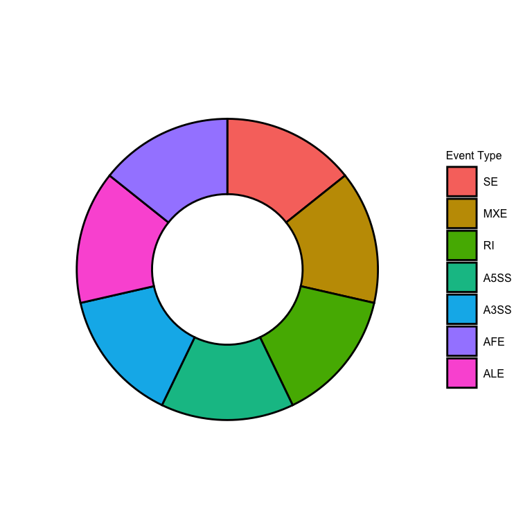

```r
# Retrieve sample metadata
df.pheno <- marvel.demo$SplicePheno

# Define sample ids
sample.ids <- df.pheno[which(df.pheno$cell.type=="iPSC"), "sample.id"]

# Tabulate expressed events
marvel.demo <- CountEvents(MarvelObject=marvel.demo,
                           sample.ids=sample.ids,
                           min.cells=5
                           )

# Output (1): Plot
marvel.demo$N.Events$Plot
```

```r
# Output (2): Table
marvel.demo$N.Events$Table
```

```
##   event_type freq      pct
## 1         SE   10 14.28571
## 2        MXE   10 14.28571
## 3         RI   10 14.28571
## 4       A5SS   10 14.28571
## 5       A3SS   10 14.28571
## 6        ALE   10 14.28571
## 7        AFE   10 14.28571
```

- `min.cells` option. Here, we required the splicing event to be expressed in at least 5 cells for the splicing event to be included for analysis.

## Endoderm cells

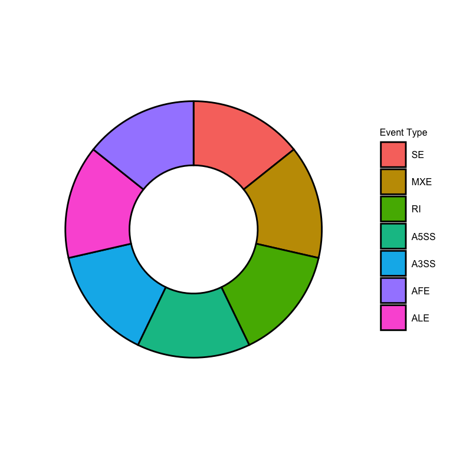

```r
# Retrieve sample metadata
df.pheno <- marvel.demo$SplicePheno

# Define sample ids
sample.ids <- df.pheno[which(df.pheno$cell.type=="Endoderm"), "sample.id"]

# Tabulate expressed events
marvel.demo <- CountEvents(MarvelObject=marvel.demo,
                           sample.ids=sample.ids,
                           min.cells=5
                           )

# Output (1): Plot
marvel.demo$N.Events$Plot
```

```r
# Output (2): Table
marvel.demo$N.Events$Table
```

```
##   event_type freq      pct
## 1         SE   10 14.28571
## 2        MXE   10 14.28571
## 3         RI   10 14.28571
## 4       A5SS   10 14.28571
## 5       A3SS   10 14.28571
## 6        ALE   10 14.28571
## 7        AFE   10 14.28571
```

# Modality analysis

The PSI distribution for a given splicing event in a given cell population may be assigned to a modality class. Modalities are simply discrete splicing patterns categories. This will enable us to understand the isoform expression pattern for a given splicing event in a given cell population.  
The five main modalities are included, excluded, bimodal, middle, and multimodal (Song *et al.*, 2017). MARVEL provides finer classification of splicing patterns by further stratifying included and excluded modalities into primary and dispersed.

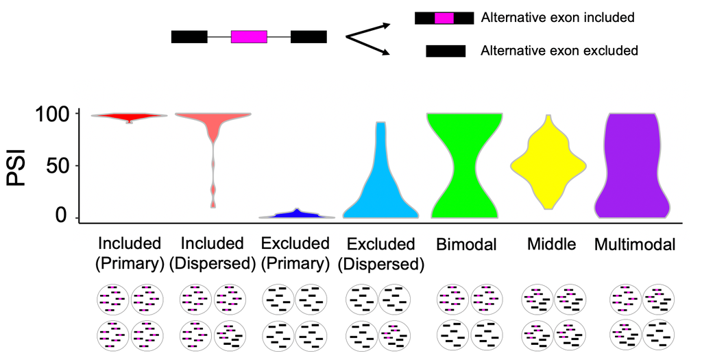

## iPSC

```r
# Retrieve sample metadata
df.pheno <- marvel.demo$SplicePheno

# Define sample IDs
sample.ids <- df.pheno[which(df.pheno$cell.type=="iPSC"), "sample.id"]

# Assign modality
marvel.demo <- AssignModality(MarvelObject=marvel.demo,
                              sample.ids=sample.ids,
                              min.cells=5,
                              seed=1
                              )

marvel.demo$Modality$Results[1:5, c("tran_id", "event_type", "gene_id", "gene_short_name", "modality.bimodal.adj")]
```

```
##                                                                       tran_id
## 1    chr1:62196435:62196528:+@chr1:62203447:62203557:+@chr1:62206519:62207636
## 2 chr15:24962114:24962209:+@chr15:24967029:24967152:+@chr15:24967932:24968082
## 3 chr15:24962114:24962209:+@chr15:24967029:24967240:+@chr15:24967932:24968082
## 4 chr17:51153576:51153662:+@chr17:51154225:51154444:+@chr17:51155651:51155780
## 5 chr10:78037194:78037304:+@chr10:78037439:78037441:+@chr10:78040204:78040225
##   event_type            gene_id gene_short_name modality.bimodal.adj
## 1         SE  ENSG00000240563.2           L1TD1     Excluded.Primary
## 2         SE ENSG00000128739.22           SNRPN   Excluded.Dispersed
## 3         SE ENSG00000128739.22           SNRPN   Excluded.Dispersed
## 4         SE  ENSG00000239672.7            NME1   Excluded.Dispersed
## 5         SE ENSG00000138326.20           RPS24   Excluded.Dispersed
```

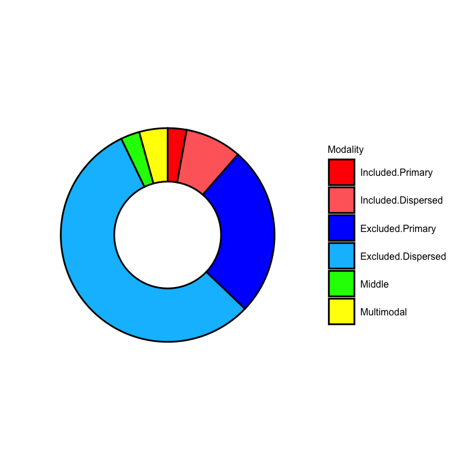

```r
# Tabulate modality proportion (overall)
marvel.demo <- PropModality(MarvelObject=marvel.demo,
                            modality.column="modality.bimodal.adj",
                            modality.type="extended",
                            event.type=c("SE", "MXE", "RI", "A5SS", "A3SS", "AFE", "ALE"),
                            across.event.type=FALSE
                            )

marvel.demo$Modality$Prop$DoughnutChart$Plot
```

```r
marvel.demo$Modality$Prop$DoughnutChart$Table
```

```
##             modality freq       pct
## 4   Included.Primary    2  2.857143
## 3 Included.Dispersed    6  8.571429
## 2   Excluded.Primary   18 25.714286
## 1 Excluded.Dispersed   39 55.714286
## 5             Middle    2  2.857143
## 6         Multimodal    3  4.285714
```

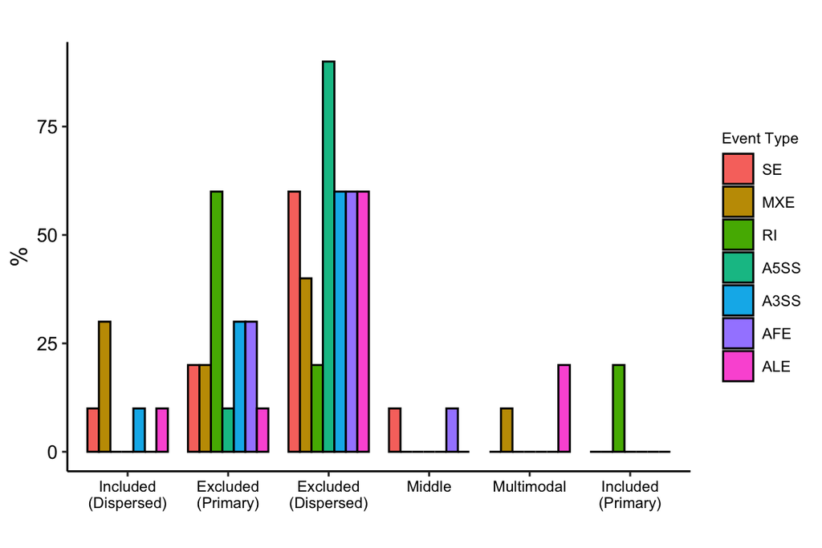

```r
# Tabulate modality proportion (by event type)
marvel.demo <- PropModality(MarvelObject=marvel.demo,
                            modality.column="modality.bimodal.adj",
                            modality.type="extended",
                            event.type=c("SE", "MXE", "RI", "A5SS", "A3SS", "AFE", "ALE"),
                            across.event.type=TRUE,
                            prop.test="fisher",
                            prop.adj="fdr",
                            xlabels.size=8
                            )

marvel.demo$Modality$Prop$BarChart$Plot
```

```r
head(marvel.demo$Modality$Prop$BarChart$Table)
```

```
##                modality freq pct event_type
## 3  Included (Dispersed)    1  10         SE
## 2    Excluded (Primary)    2  20         SE
## 1  Excluded (Dispersed)    6  60         SE
## 4                Middle    1  10         SE
## 11           Multimodal    0   0         SE
## 21   Included (Primary)    0   0         SE
```

- By stratifying the modalities by splicing event type, we can assess if certain modalities are more enriched in a given splicing event type.
- For example, here we observed the excluded modality to be the most prevalent in retained-intron (RI).
- This suggests that most isoforms do not retain introns, and this is consistent with the role of mRNA splicing in intron removal, i.e., only a small proportion of isoforms retain their introns as a mechanism of regulating gene expression.

## Endoderm

```r
# Retrieve sample metadata
df.pheno <- marvel.demo$SplicePheno

# Define sample IDs
sample.ids <- df.pheno[which(df.pheno$cell.type=="Endoderm"), "sample.id"]

# Assign modality
marvel.demo <- AssignModality(MarvelObject=marvel.demo,
                              sample.ids=sample.ids,
                              min.cells=5,
                              seed=1
                              )

marvel.demo$Modality$Results[1:5, c("tran_id", "event_type", "gene_id", "gene_short_name", "modality.bimodal.adj")]
```

```
##                                                                       tran_id
## 1    chr1:62196435:62196528:+@chr1:62203447:62203557:+@chr1:62206519:62207636
## 2 chr15:24962114:24962209:+@chr15:24967029:24967152:+@chr15:24967932:24968082
## 3 chr15:24962114:24962209:+@chr15:24967029:24967240:+@chr15:24967932:24968082
## 4 chr17:51153576:51153662:+@chr17:51154225:51154444:+@chr17:51155651:51155780
## 5 chr10:78037194:78037304:+@chr10:78037439:78037441:+@chr10:78040204:78040225
##   event_type            gene_id gene_short_name modality.bimodal.adj
## 1         SE  ENSG00000240563.2           L1TD1   Excluded.Dispersed
## 2         SE ENSG00000128739.22           SNRPN     Excluded.Primary
## 3         SE ENSG00000128739.22           SNRPN   Excluded.Dispersed
## 4         SE  ENSG00000239672.7            NME1     Excluded.Primary
## 5         SE ENSG00000138326.20           RPS24   Excluded.Dispersed
```

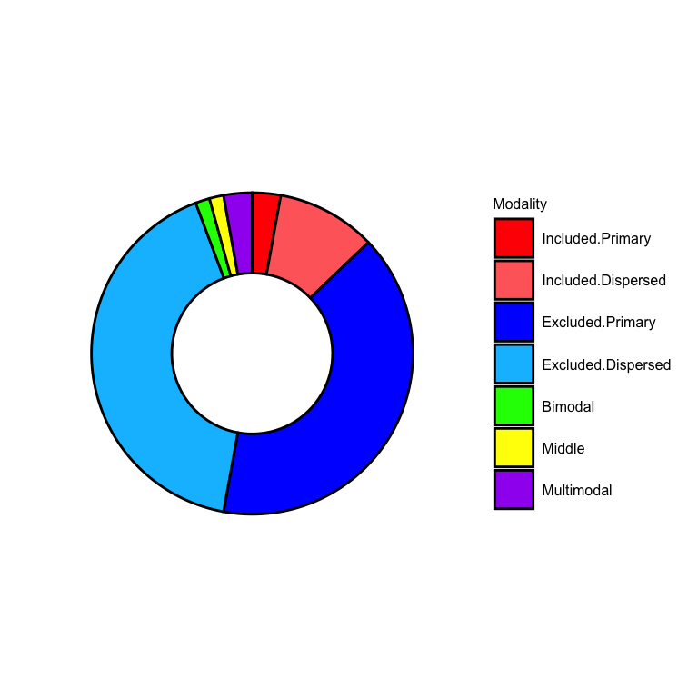

```r
# Tabulate modality proportion (overall)
marvel.demo <- PropModality(MarvelObject=marvel.demo,
                            modality.column="modality.bimodal.adj",
                            modality.type="extended",
                            event.type=c("SE", "MXE", "RI", "A5SS", "A3SS", "AFE", "ALE"),
                            across.event.type=FALSE
                            )

marvel.demo$Modality$Prop$DoughnutChart$Plot
```

```r
marvel.demo$Modality$Prop$DoughnutChart$Table
```

```
##             modality freq       pct
## 5   Included.Primary    2  2.857143
## 4 Included.Dispersed    7 10.000000
## 3   Excluded.Primary   28 40.000000
## 2 Excluded.Dispersed   29 41.428571
## 1            Bimodal    1  1.428571
## 6             Middle    1  1.428571
## 7         Multimodal    2  2.857143
```

- Similar to iPSCs, the most prevalent modality types are included and excluded among endoderm cells.
- Similar to iPSCs, the bimodal, middle, and multimodal modalities constitute a small proportion of splicing patterns among endoderm cells.

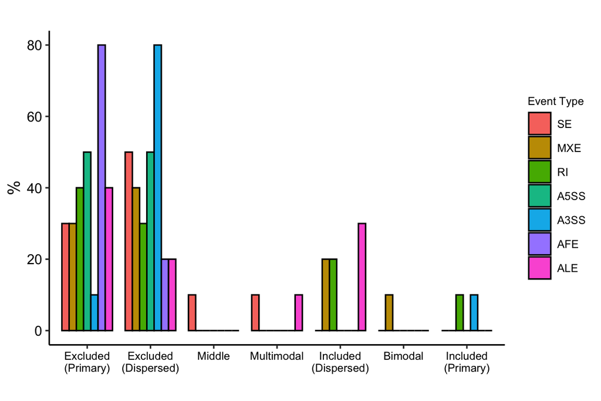

```r
# Tabulate modality proportion (by event type)
marvel.demo <- PropModality(MarvelObject=marvel.demo,
                            modality.column="modality.bimodal.adj",
                            modality.type="extended",
                            event.type=c("SE", "MXE", "RI", "A5SS", "A3SS", "AFE", "ALE"),
                            across.event.type=TRUE,
                            prop.test="fisher",
                            prop.adj="fdr",
                            xlabels.size=8
                           )

marvel.demo$Modality$Prop$BarChart$Plot
```

```r
head(marvel.demo$Modality$Prop$BarChart$Table)
```

```
##                modality freq pct event_type
## 2    Excluded (Primary)    3  30         SE
## 1  Excluded (Dispersed)    5  50         SE
## 3                Middle    1  10         SE
## 4            Multimodal    1  10         SE
## 11 Included (Dispersed)    0   0         SE
## 21              Bimodal    0   0         SE
```

- Similar to iPSCs, we observe the excluded modality to be the most prevalent in retained-intron (RI) among endoderm cells.

# Differential analysis

Differential analysis is the cornerstone of RNA-sequencing analysis. This is the first step to identify candidate genes and isoforms for downstream experimental validation.  
Statistical tests that compare the mean expression values between two cell populations, such as Wilcox, are suitable for differential gene expression analysis.  
However, the mean alone will not be sufficient to detect changes in splicing patterns. For example, based on the mean alone, it may not be possible to distinguish between splicing events with bimodal, middle, and multimodal splicing patterns. Therefore, in lieu of comparing mean, MARVEL compares the overall PSI distribution between two cell populations.

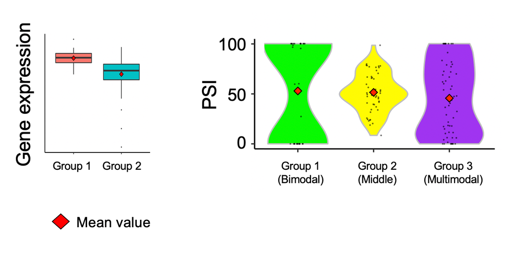

## Differential gene expression analysis

```r
# Define cell groups
    # Retrieve sample metadata
    df.pheno <- marvel.demo$SplicePheno

    # Cell group 1 (reference)
    cell.group.g1 <- df.pheno[which(df.pheno$cell.type=="iPSC"), "sample.id"]

    # Cell group 2
    cell.group.g2 <- df.pheno[which(df.pheno$cell.type=="Endoderm"), "sample.id"]

# DE analysis
marvel.demo <- CompareValues(MarvelObject=marvel.demo,
                             cell.group.g1=cell.group.g1,
                             cell.group.g2=cell.group.g2,
                             min.cells=3,
                             method="t.test",
                             method.adjust="fdr",
                             level="gene",
                             show.progress=FALSE
                             )

marvel.demo$DE$Exp$Table[1:5, ]
```

```
##              gene_id gene_short_name      gene_type n.cells.g1 n.cells.g2
## 1 ENSG00000128739.22           SNRPN protein_coding         15         15
## 2 ENSG00000067225.18             PKM protein_coding         15         15
## 3 ENSG00000137309.19           HMGA1 protein_coding         15         15
## 4  ENSG00000239672.7            NME1 protein_coding         15         13
## 5  ENSG00000120675.6         DNAJC15 protein_coding         14         15
##    mean.g1   mean.g2     log2fc statistic        p.val    p.val.adj
## 1 9.203101  8.331827 -0.8712731  1.322837 9.876425e-07 5.333270e-05
## 2 7.896393 10.207866  2.3114738  1.322837 2.845515e-06 7.682892e-05
## 3 7.276139  6.060553 -1.2155857  1.322837 5.694655e-06 1.025038e-04
## 4 8.985144  5.082584 -3.9025599  1.322837 5.476249e-05 6.832612e-04
## 5 3.871605  6.065549  2.1939435  1.322837 6.484850e-05 6.832612e-04
```

- `min.cells` option. Here, we required the gene to be expressed in at least 3 cells in either iPSCs or endoderm cells for the gene to be included for analysis.
- `show.progress` option. For the brevity of the tutorial, we did not track the progress of differential expression analysis. But users are advised to set this option to `TRUE` when running this step on their own devices.

## Volcano plot: Genes

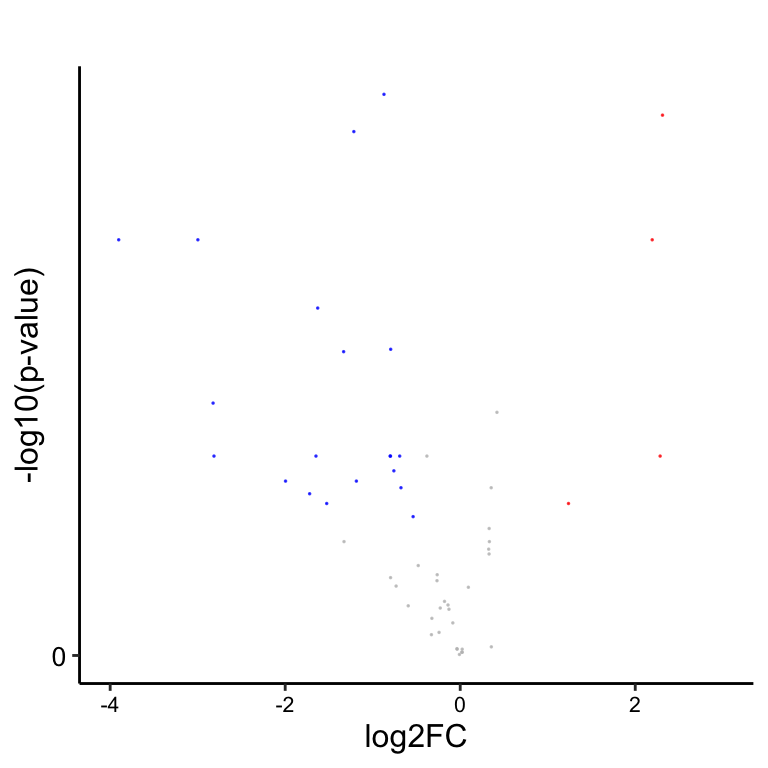

```r
# Plot DE results
marvel.demo <- PlotDEValues(MarvelObject=marvel.demo,
                            pval=0.10,
                            log2fc=0.5,
                            point.size=0.1,
                            level="gene.global",
                            anno=FALSE
                            )

marvel.demo$DE$Exp.Global$Plot
```

```r
marvel.demo$DE$Exp.Global$Summary
```

```
##    sig freq
## 1   up    4
## 2 down   20
## 3 n.s.   30
```

```r
head(marvel.demo$DE$Exp.Global$Table[,c("gene_id", "gene_short_name", "sig")])
```

```
##              gene_id gene_short_name  sig
## 1 ENSG00000128739.22           SNRPN down
## 2 ENSG00000067225.18             PKM   up
## 3 ENSG00000137309.19           HMGA1 down
## 4  ENSG00000239672.7            NME1 down
## 5  ENSG00000120675.6         DNAJC15   up
## 6 ENSG00000154473.18            BUB3 down
```

- `pval` option. The adjusted p-value, below which, the gene is considered to be differentially expressed.
- `log2fc` option. The absolute log2 fold change, above which, the gene is considered to be differentially expressed.

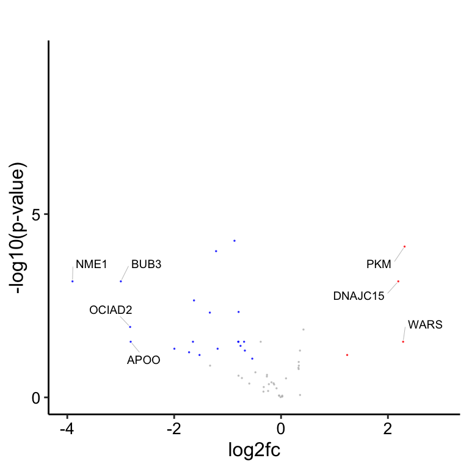

```r
# Plot DE results with annotation of selected genes
    # Retrieve DE output table
    results <- marvel.demo$DE$Exp$Table

    # Retrieve top genes
    index <- which(results$log2fc > 2 | results$log2fc < -2)
    gene_short_names <- results[index, "gene_short_name"]

    # Plot
    marvel.demo <- PlotDEValues(MarvelObject=marvel.demo,
                                pval=0.10,
                                log2fc=0.5,
                                point.size=0.1,
                                xlabel.size=10,
                                level="gene.global",
                                anno=TRUE,
                                anno.gene_short_name=gene_short_names
                                )

    marvel.demo$DE$Exp.Global$Plot
```

## Differential splicing analysis

```r
marvel.demo <- CompareValues(MarvelObject=marvel.demo,
                             cell.group.g1=cell.group.g1,
                             cell.group.g2=cell.group.g2,
                             min.cells=5,
                             method=c("ad", "dts"),
                             method.adjust="fdr",
                             level="splicing",
                             event.type=c("SE", "MXE", "RI", "A5SS", "A3SS", "ALE", "AFE"),
                             show.progress=FALSE
                             )

head(marvel.demo$DE$PSI$Table[["ad"]])
```

```
##                                                                         tran_id
## 110                       chr17:8383254:8382781|8383157:-@chr17:8382143:8382315
## 210               chr17:8383157:8383193|8382781:8383164:-@chr17:8382143:8382315
## 310 chr15:24962114:24962209:+@chr15:24967029:24967152:+@chr15:24967932:24968082
## 410               chr8:144792587:144792245|144792366:-@chr8:144791992:144792140
## 55      chr8:144792366:144792423|144792245:144792389:-@chr8:144791992:144792140
## 61      chr5:150449703:150449739|150449492:150449696:-@chr5:150447585:150447735
##     event_type            gene_id gene_short_name      gene_type n.cells.g1
## 110       A5SS ENSG00000161970.15           RPL26 protein_coding         15
## 210        AFE ENSG00000161970.15           RPL26 protein_coding         15
## 310         SE ENSG00000128739.22           SNRPN protein_coding         15
## 410       A5SS ENSG00000161016.17            RPL8 protein_coding         15
## 55         AFE ENSG00000161016.17            RPL8 protein_coding         15
## 61         AFE ENSG00000164587.13           RPS14 protein_coding         15
##     n.cells.g2  mean.g1    mean.g2 mean.diff statistic      p.val    p.val.adj
```

[output cut: 20 more lines]

```r
head(marvel.demo$DE$PSI$Table[["dts"]])
```

```
##                                                                         tran_id
## 4   chr10:78037194:78037304:+@chr10:78040204:78040225:+@chr10:78040615:78040747
## 5   chr11:85981129:85981228:-@chr11:85978070:85978093:-@chr11:85976623:85976682
## 23      chr4:108620569:108620600|108620656:108620712:+@chr4:108621951:108622024
## 1                                   chr7:5528719:5528564:-@chr7:5528344:5528281
## 2                               chr6:73519228:73519128:-@chr6:73519064:73518932
## 110 chr15:24962114:24962209:+@chr15:24967029:24967152:+@chr15:24967932:24968082
##     event_type            gene_id gene_short_name      gene_type n.cells.g1
## 4           SE ENSG00000138326.20           RPS24 protein_coding         15
## 5           SE ENSG00000073921.18          PICALM protein_coding          8
## 23         AFE ENSG00000109475.16           RPL34 protein_coding         15
## 1           RI ENSG00000075624.16            ACTB protein_coding         15
## 2           RI ENSG00000156508.18          EEF1A1 protein_coding         15
## 110         SE ENSG00000128739.22           SNRPN protein_coding         15
##     n.cells.g2   mean.g1   mean.g2  mean.diff statistic p.val p.val.adj
```

[output cut: 20 more lines]

## Distance plot: Splicing

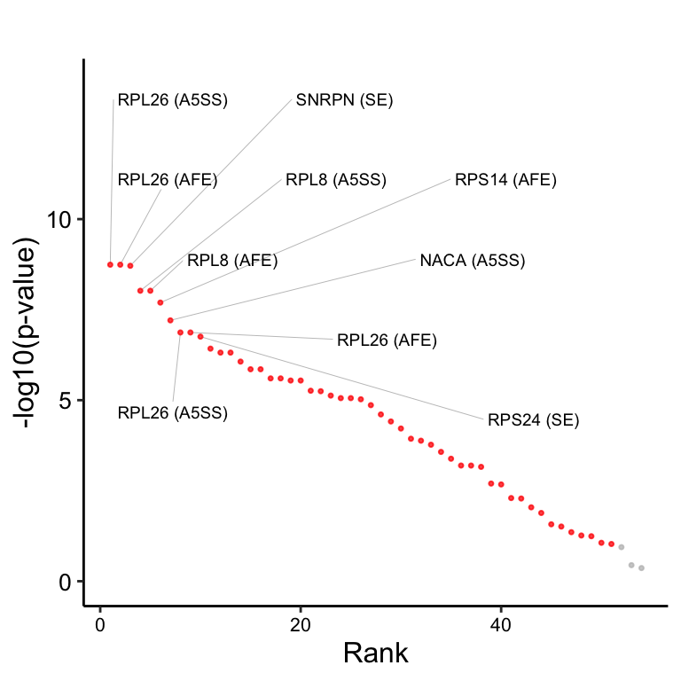

```r
marvel.demo <- PlotDEValues(MarvelObject=marvel.demo,
                       method="ad",
                       pval=0.10,
                       level="splicing.distance",
                       anno=TRUE,
                       anno.tran_id=marvel.demo$DE$PSI$Table[["ad"]]$tran_id[c(1:10)]
                       )

marvel.demo$DE$PSI$Plot[["ad"]]
```

- `method` option. Plot results for `ad` statistical test.
- `pval` option. The adjusted p-value, below which, the splicing event is considered to be differentially spliced.
- `level` option. When set to `"splicing.distance"`, the distance statistic will be used to plot the DE results. Only applicable when `method` set to `"ad"` or `"dts"`. When set to `splicing.mean`. The typical volcano plot is returned, and the `delta` option may be used.
- `delta` option. when `level` set to `"splicing.mean"`, the absolute differences in mean PSI values between the two cell populations, above which, the splicing event is considered to be differentially spliced.

## Differential (spliced) gene analysis

Next, we will perform differential gene expression analysis only on the differentially spliced genes. This will enable us to investigate the gene-splicing relationship between iPSCs and endoderm cells downstream.

```r
marvel.demo <- CompareValues(MarvelObject=marvel.demo,
                             cell.group.g1=cell.group.g1,
                             cell.group.g2=cell.group.g2,
                             psi.method=c("ad", "dts"),
                             psi.pval=c(0.10, 0.10),
                             psi.delta=0,
                             method.de.gene="t.test",
                             method.adjust.de.gene="fdr",
                             downsample=FALSE,
                             show.progress=FALSE,
                             level="gene.spliced"
                             )

head(marvel.demo$DE$Exp.Spliced$Table)
```

```
##              gene_id gene_short_name      gene_type n.cells.g1 n.cells.g2
## 1 ENSG00000128739.22           SNRPN protein_coding         15         15
## 2 ENSG00000067225.18             PKM protein_coding         15         15
## 3 ENSG00000137309.19           HMGA1 protein_coding         15         15
## 4  ENSG00000239672.7            NME1 protein_coding         15         13
## 5  ENSG00000120675.6         DNAJC15 protein_coding         14         15
## 6 ENSG00000154473.18            BUB3 protein_coding         15         14
##    mean.g1   mean.g2     log2fc statistic        p.val    p.val.adj
## 1 9.203101  8.331827 -0.8712731  1.322837 9.876425e-07 3.851806e-05
## 2 7.896393 10.207866  2.3114738  1.322837 2.845515e-06 5.548755e-05
## 3 7.276139  6.060553 -1.2155857  1.322837 5.694655e-06 7.403052e-05
## 4 8.985144  5.082584 -3.9025599  1.322837 5.476249e-05 4.934664e-04
## 5 3.871605  6.065549  2.1939435  1.322837 6.484850e-05 4.934664e-04
## 6 7.893652  4.895821 -2.9978306  1.322837 7.591791e-05 4.934664e-04
```

- `psi.method`, `psi.pval`, and `psi.delta` options. For defining differentially spliced events whose corresponding genes will be included for differential gene expression analysis.
- `method.de.gene` and `method.adjust.de.gene` options. The statistical test and multiple testing method for differential gene expression analysis.

## Volcano plot: Spliced genes

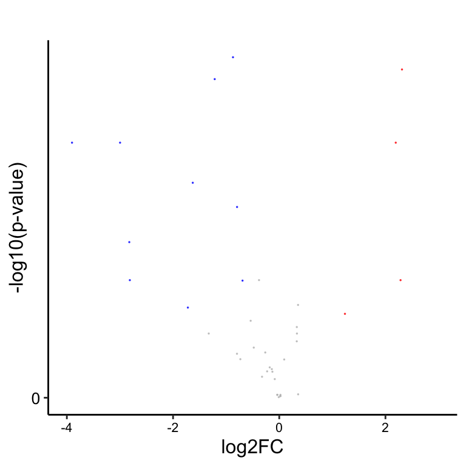

```r
# Plot: No annotation
marvel.demo <- PlotDEValues(MarvelObject=marvel.demo,
                            method=c("ad", "dts"),
                            psi.pval=c(0.10, 0.10),
                            psi.delta=0,
                            gene.pval=0.10,
                            gene.log2fc=0.5,
                            point.size=0.1,
                            xlabel.size=8,
                            level="gene.spliced",
                            anno=FALSE
                            )

marvel.demo$DE$Exp.Spliced$Plot
```

```r
marvel.demo$DE$Exp.Spliced$Summary
```

```
##    sig freq
## 1   up    4
## 2 down   10
## 3 n.s.   25
```

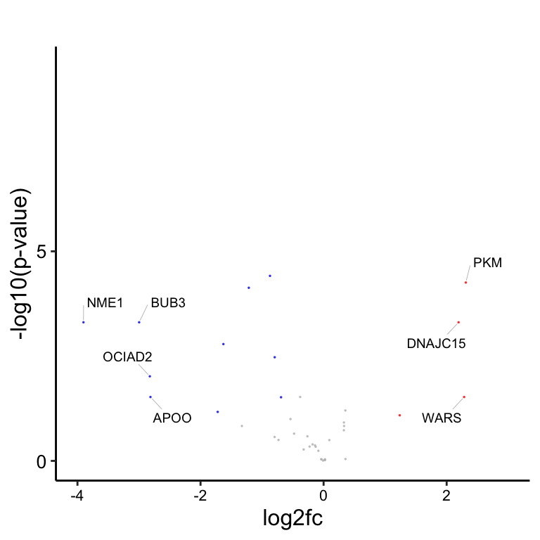

```r
# Plot: Annotate top genes
results <- marvel.demo$DE$Exp.Spliced$Table

index <- which((results$log2fc > 2 | results$log2fc < -2) & -log10(results$p.val.adj) > 1)
gene_short_names <- results[index, "gene_short_name"]

marvel.demo <- PlotDEValues(MarvelObject=marvel.demo,
                            method=c("ad", "dts"),
                            psi.pval=c(0.10, 0.10),
                            psi.delta=0,
                            gene.pval=0.10,
                            gene.log2fc=0.5,
                            point.size=0.1,
                            xlabel.size=8,
                            level="gene.spliced",
                            anno=TRUE,
                            anno.gene_short_name=gene_short_names
                            )

marvel.demo$DE$Exp.Spliced$Plot
```

# Principal component analysis

## DE genes

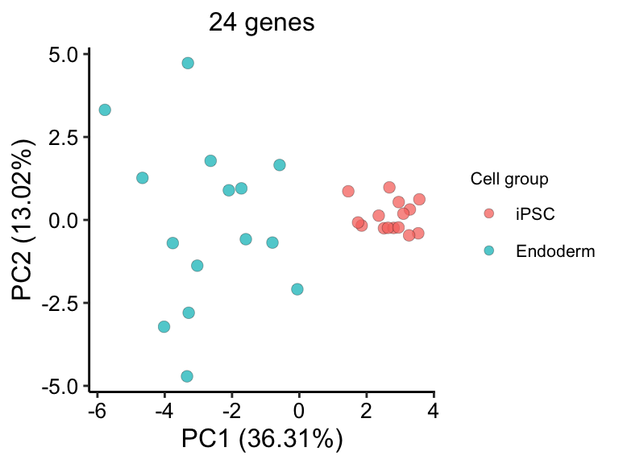

```r
# Define sample groups
    # Retrieve sample metadata
    df.pheno <- marvel.demo$SplicePheno

    # Group 1
    sample.ids.1 <- df.pheno[which(df.pheno$cell.type=="iPSC"), "sample.id"]

    # Group 2
    sample.ids.2 <- df.pheno[which(df.pheno$cell.type=="Endoderm"), "sample.id"]

    # Merge
    cell.group.list <- list("iPSC"=sample.ids.1,
                            "Endoderm"=sample.ids.2
                            )

# Retrieve DE genes
  # Retrieve DE result table
  results.de.exp <- marvel.demo$DE$Exp$Table

  # Retrieve relevant gene_ids
  index <- which(results.de.exp$p.val.adj < 0.10 & abs(results.de.exp$log2fc) > 0.5)
  gene_ids <- results.de.exp[index, "gene_id"]

# Reduce dimension
marvel.demo <- RunPCA(MarvelObject=marvel.demo,
                      cell.group.column="cell.type",
                      cell.group.order=c("iPSC", "Endoderm"),
                      cell.group.colors=NULL,
                      min.cells=5,
                      features=gene_ids,
                      point.size=2.5,
                      level="gene"
                      )

marvel.demo$PCA$Exp$Plot
```

## DE splicing

```r
# Retrieve DE tran_ids
method <- c("ad", "dts")

tran_ids.list <- list()

for(i in 1:length(method)) {

    results.de.psi <- marvel.demo$DE$PSI$Table[[method[i]]]
    index <- which(results.de.psi$p.val.adj < 0.10 & results.de.psi$outlier==FALSE)
    tran_ids <- results.de.psi[index, "tran_id"]
    tran_ids.list[[i]] <- tran_ids

}

tran_ids <- unique(unlist(tran_ids.list))

# Reduce dimension
marvel.demo <- RunPCA(MarvelObject=marvel.demo,
                      cell.group.column="cell.type",
                      cell.group.order=c("iPSC", "Endoderm"),
                      cell.group.colors=NULL,
                      min.cells=5,
                      features=tran_ids,
                      point.size=2.5,
                      level="splicing",
                      method.impute="random",
                      seed=1
                      )
```

```
## [1] "30 of 30 cells specified were found and retained"
## [1] "52 of 52 splicing events expressed in at least 5 cells and are retained"
## [1] "Performing pre-flight checks..."
```

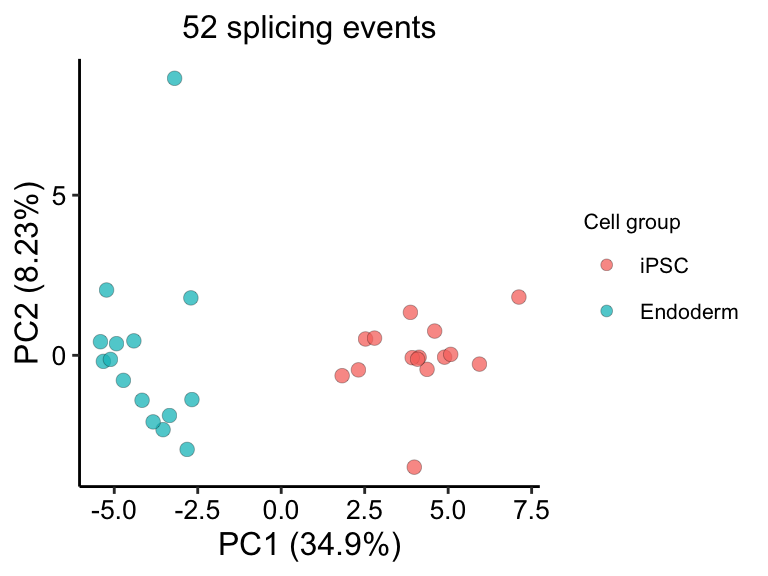

```r
marvel.demo$PCA$PSI$Plot
```

## non-DE genes

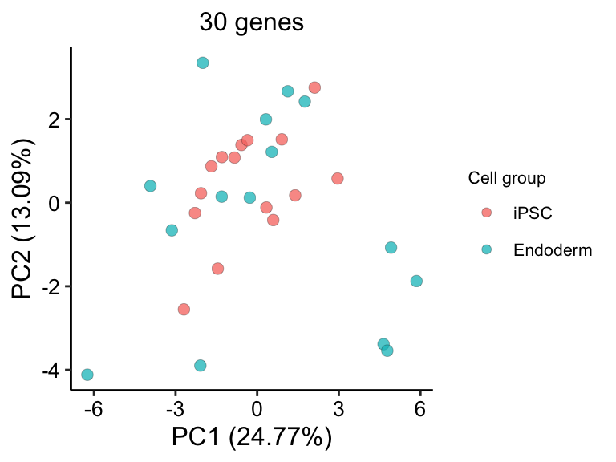

```r
# Retrieve relevant gene_ids
results.de.exp <- marvel.demo$DE$Exp$Table
index <- which(results.de.exp$p.val.adj < 0.10 & abs(results.de.exp$log2fc) > 0.5)
gene_ids <- results.de.exp[-index, "gene_id"]

# Reduce dimension
marvel.demo <- RunPCA(MarvelObject=marvel.demo,
                      cell.group.column="cell.type",
                      cell.group.order=c("iPSC", "Endoderm"),
                      cell.group.colors=NULL,
                      min.cells=5,
                      features=gene_ids,
                      point.size=2.5,
                      level="gene"
                      )

marvel.demo$PCA$Exp$Plot
```

- As expected, using non-DE genes, we were not able to distinguish between iPSCs and endoderm cells.
- Can splicing distinguish between iPSCs and endoderm cells. when non-DE genes couldn’t?

## Splicing (non-DE genes)

```r
# Retrieve non-DE gene_ids
results.de.exp <- marvel.demo$DE$Exp$Table
index <- which(results.de.exp$p.val.adj > 0.10 )
gene_ids <- results.de.exp[, "gene_id"]

# Retrieve tran_ids
df.feature <- do.call(rbind.data.frame, marvel.demo$SpliceFeatureValidated)
df.feature <- df.feature[which(df.feature$gene_id %in% gene_ids), ]

# Reduce dimension: All DE splicing events
tran_ids <- df.feature$tran_id

marvel.demo <- RunPCA(MarvelObject=marvel.demo,
                      cell.group.column="cell.type",
                      cell.group.order=c("iPSC", "Endoderm"),
                      cell.group.colors=NULL,
                      min.cells=5,
                      features=tran_ids,
                      point.size=2.5,
                      level="splicing",
                      method.impute="random",
                      seed=1
                      )
```

```
## [1] "30 of 30 cells specified were found and retained"
## [1] "70 of 70 splicing events expressed in at least 5 cells and are retained"
## [1] "Performing pre-flight checks..."
```

```r
plot.all <- marvel.demo$PCA$PSI$Plot

# Reduce dimension: SE
tran_ids <- df.feature[which(df.feature$event_type=="SE"), "tran_id"]

marvel.demo <- RunPCA(MarvelObject=marvel.demo,
                      cell.group.column="cell.type",
                      cell.group.order=c("iPSC", "Endoderm"),
                      cell.group.colors=NULL,
                      min.cells=5,
                      features=tran_ids,
                      point.size=2.5,
                      level="splicing",
                      method.impute="random",
                      seed=1
                      )
```

```
## [1] "30 of 30 cells specified were found and retained"
## [1] "10 of 10 splicing events expressed in at least 5 cells and are retained"
## [1] "Performing pre-flight checks..."
```

```r
plot.se <- marvel.demo$PCA$PSI$Plot

# Reduce dimension: MXE
tran_ids <- df.feature[which(df.feature$event_type=="MXE"), "tran_id"]

marvel.demo <- RunPCA(MarvelObject=marvel.demo,
                      cell.group.column="cell.type",
                      cell.group.order=c("iPSC", "Endoderm"),
                      cell.group.colors=NULL,
                      min.cells=5,
                      features=tran_ids,
                      point.size=2.5,
                      level="splicing",
                      method.impute="random",
                      seed=1
                      )
```

```
## [1] "30 of 30 cells specified were found and retained"
## [1] "10 of 10 splicing events expressed in at least 5 cells and are retained"
## [1] "Performing pre-flight checks..."
```

```r
plot.mxe <- marvel.demo$PCA$PSI$Plot

# Reduce dimension: RI
tran_ids <- df.feature[which(df.feature$event_type=="RI"), "tran_id"]

marvel.demo <- RunPCA(MarvelObject=marvel.demo,
                      cell.group.column="cell.type",
                      cell.group.order=c("iPSC", "Endoderm"),
                      cell.group.colors=NULL,
                      min.cells=5,
                      features=tran_ids,
                      point.size=2.5,
                      level="splicing",
                      method.impute="random",
                      seed=1
                      )
```

```
## [1] "30 of 30 cells specified were found and retained"
## [1] "10 of 10 splicing events expressed in at least 5 cells and are retained"
## [1] "Performing pre-flight checks..."
```

```r
plot.ri <- marvel.demo$PCA$PSI$Plot

# Reduce dimension: A5SS
tran_ids <- df.feature[which(df.feature$event_type=="A5SS"), "tran_id"]

marvel.demo <- RunPCA(MarvelObject=marvel.demo,
                      cell.group.column="cell.type",
                      cell.group.order=c("iPSC", "Endoderm"),
                      cell.group.colors=NULL,
                      min.cells=5,
                      features=tran_ids,
                      point.size=2.5,
                      level="splicing",
                      method.impute="random",
                      seed=1
                      )
```

```
## [1] "30 of 30 cells specified were found and retained"
## [1] "10 of 10 splicing events expressed in at least 5 cells and are retained"
## [1] "Performing pre-flight checks..."
```

```r
plot.a5ss <- marvel.demo$PCA$PSI$Plot

# Reduce dimension: A3SS
tran_ids <- df.feature[which(df.feature$event_type=="A3SS"), "tran_id"]

marvel.demo <- RunPCA(MarvelObject=marvel.demo,
                      cell.group.column="cell.type",
                      cell.group.order=c("iPSC", "Endoderm"),
                      cell.group.colors=NULL,
                      min.cells=5,
                      features=tran_ids,
                      point.size=2.5,
                      level="splicing",
                      method.impute="random",
                      seed=1
                      )
```

```
## [1] "30 of 30 cells specified were found and retained"
## [1] "10 of 10 splicing events expressed in at least 5 cells and are retained"
## [1] "Performing pre-flight checks..."
```

```r
plot.a3ss <- marvel.demo$PCA$PSI$Plot

# Reduce dimension: AFE
tran_ids <- df.feature[which(df.feature$event_type=="AFE"), "tran_id"]

marvel.demo <- RunPCA(MarvelObject=marvel.demo,
                      cell.group.column="cell.type",
                      cell.group.order=c("iPSC", "Endoderm"),
                      cell.group.colors=NULL,
                      min.cells=5,
                      features=tran_ids,
                      point.size=2.5,
                      level="splicing",
                      method.impute="random",
                      seed=1
                      )
```

```
## [1] "30 of 30 cells specified were found and retained"
## [1] "10 of 10 splicing events expressed in at least 5 cells and are retained"
## [1] "Performing pre-flight checks..."
```

```r
plot.afe <- marvel.demo$PCA$PSI$Plot

# Reduce dimension:
tran_ids <- df.feature[which(df.feature$event_type=="ALE"), "tran_id"]

marvel.demo <- RunPCA(MarvelObject=marvel.demo,
                      cell.group.column="cell.type",
                      cell.group.order=c("iPSC", "Endoderm"),
                      cell.group.colors=NULL,
                      min.cells=5,
                      features=tran_ids,
                      point.size=2.5,
                      level="splicing",
                      method.impute="random",
                      seed=1
                      )
```

```
## [1] "30 of 30 cells specified were found and retained"
## [1] "10 of 10 splicing events expressed in at least 5 cells and are retained"
## [1] "Performing pre-flight checks..."
```

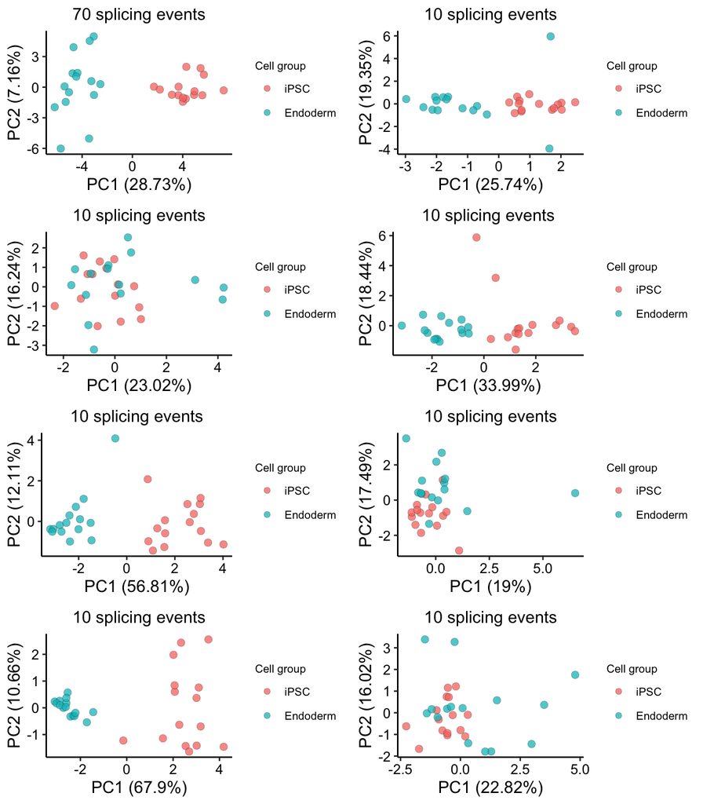

```r
plot.ale <- marvel.demo$PCA$PSI$Plot

# Arrange and view plots
# Read plots from right to left for each row
grid.arrange(plot.all, plot.se,
             plot.mxe, plot.ri,
             plot.a5ss, plot.a3ss,
             plot.afe, plot.ale,
             nrow=4)
```

- Note that while non-DE genes were not successful in distinguishing between iPSCs and endoderm cells, splicing events of non-DE genes were successful in doing so. This suggests that splicing may be an additional and invisible source of complexity underlying gene expression profile.

# Modality dynamics

Modality dynamics reveals the change in splicing pattern (modality) from one cell population (iPSCs) to another (endoderm cells). The modality dynamics from one cell population to another can be classified into three categories, namely explicit, implicit, and restricted.

- **Explicit** modality change involves one of the main modality classess, namely included, excluded, bimodal, middle, and multimodal. For example, included to bimodal would constitute an explicity modality change.
- **Implicit** modality change involves one of the sub- modality classess, namely primary and dispersed. For example, included-primary to included-dispersed would constitute an implicit modality change.
- **Restricted** modality change involves limited change in splicing pattern. For example, both cell populations may have the same modality class but different mean PSI values.

Here, we will perform modality dynamics analysis among differentially spliced events. Representative examples for each modality dynamics classification will also be shown. This section also introduces our ad hoc plot function `PlotValues` for plotting selected splicing events.

## Assign dynamics

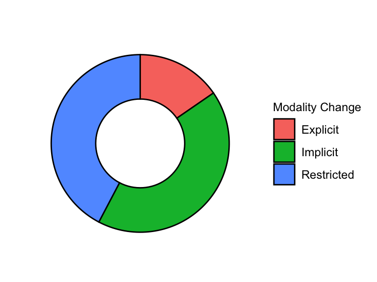

```r
# Define sample groups
    # Retrieve sample metadata
    df.pheno <- marvel.demo$SplicePheno

    # Group 1
    sample.ids.1 <- df.pheno[which(df.pheno$cell.type=="iPSC"), "sample.id"]

    # Group 2
    sample.ids.2 <- df.pheno[which(df.pheno$cell.type=="Endoderm"), "sample.id"]

    # Merge
    cell.group.list <- list("iPSC"=sample.ids.1,
                            "Endoderm"=sample.ids.2
                            )

# Assign modality dynamics
marvel.demo <- ModalityChange(MarvelObject=marvel.demo,
                       method=c("ad", "dts"),
                       psi.pval=c(0.10, 0.10)
                       )

marvel.demo$DE$Modality$Plot
```

```r
head(marvel.demo$DE$Modality$Table)
```

```
##                                                                       tran_id
## 1                       chr17:8383254:8382781|8383157:-@chr17:8382143:8382315
## 2               chr17:8383157:8383193|8382781:8383164:-@chr17:8382143:8382315
## 3 chr15:24962114:24962209:+@chr15:24967029:24967152:+@chr15:24967932:24968082
## 4               chr8:144792587:144792245|144792366:-@chr8:144791992:144792140
## 5     chr8:144792366:144792423|144792245:144792389:-@chr8:144791992:144792140
## 6     chr5:150449703:150449739|150449492:150449696:-@chr5:150447585:150447735
##   event_type            gene_id gene_short_name      gene_type
## 1       A5SS ENSG00000161970.15           RPL26 protein_coding
## 2        AFE ENSG00000161970.15           RPL26 protein_coding
## 3         SE ENSG00000128739.22           SNRPN protein_coding
## 4       A5SS ENSG00000161016.17            RPL8 protein_coding
## 5        AFE ENSG00000161016.17            RPL8 protein_coding
## 6        AFE ENSG00000164587.13           RPS14 protein_coding
##   modality.bimodal.adj.g1 modality.bimodal.adj.g2 modality.change
## 1      Excluded.Dispersed        Excluded.Primary        Implicit
## 2      Excluded.Dispersed        Excluded.Primary        Implicit
## 3      Excluded.Dispersed        Excluded.Primary        Implicit
## 4      Excluded.Dispersed        Excluded.Primary        Implicit
## 5      Excluded.Dispersed        Excluded.Primary        Implicit
## 6        Excluded.Primary        Excluded.Primary      Restricted
```

```r
marvel.demo$DE$Modality$Plot.Stats
```

```
##   modality.change freq      pct
## 1        Explicit    8 15.38462
## 2        Implicit   22 42.30769
## 3      Restricted   22 42.30769
```

## Explicit

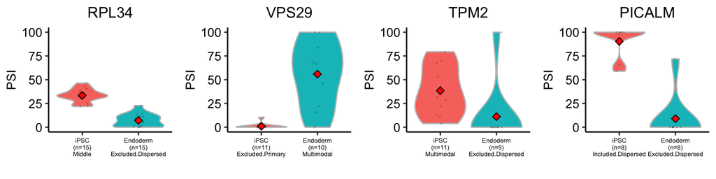

```r
# Example 1
tran_id <- "chr4:108620569:108620600|108620656:108620712:+@chr4:108621951:108622024"

marvel.demo <- PlotValues(MarvelObject=marvel.demo,
                          cell.group.list=cell.group.list,
                          feature=tran_id,
                          xlabels.size=5,
                          level="splicing",
                          min.cells=5
                          )

plot.1 <- marvel.demo$adhocPlot$PSI

# Example 2
tran_id <- "chr12:110502049:110502117:-@chr12:110499535:110499546:-@chr12:110496012:110496203"

marvel.demo <- PlotValues(MarvelObject=marvel.demo,
                          cell.group.list=cell.group.list,
                          feature=tran_id,
                          xlabels.size=5,
                          level="splicing",
                          min.cells=5
                          )

plot.2 <- marvel.demo$adhocPlot$PSI

# Example 3
tran_id <- "chr9:35685269:35685339:-@chr9:35685064:35685139:-@chr9:35684732:35684807:-@chr9:35684488:35684550"

marvel.demo <- PlotValues(MarvelObject=marvel.demo,
                          cell.group.list=cell.group.list,
                          feature=tran_id,
                          xlabels.size=5,
                          level="splicing",
                          min.cells=5
                          )

plot.3 <- marvel.demo$adhocPlot$PSI

# Example 4
tran_id <- "chr11:85981129:85981228:-@chr11:85978070:85978093:-@chr11:85976623:85976682"

marvel.demo <- PlotValues(MarvelObject=marvel.demo,
                          cell.group.list=cell.group.list,
                          feature=tran_id,
                          xlabels.size=5,
                          level="splicing",
                          min.cells=5
                          )

plot.4 <- marvel.demo$adhocPlot$PSI

# Arrange and view plots
# Read plots from right to left for each row
grid.arrange(plot.1, plot.2,
             plot.3, plot.4,
             nrow=1)
```

## Implicit

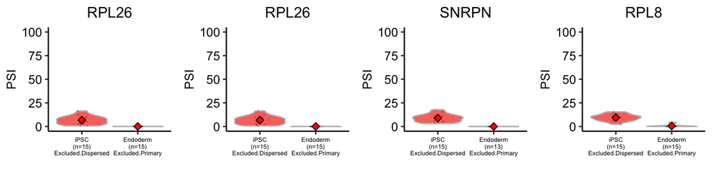

```r
# Example 1
tran_id <- "chr17:8383254:8382781|8383157:-@chr17:8382143:8382315"

marvel.demo <- PlotValues(MarvelObject=marvel.demo,
                          cell.group.list=cell.group.list,
                          feature=tran_id,
                          xlabels.size=5,
                          level="splicing",
                          min.cells=5
                          )

plot.1 <- marvel.demo$adhocPlot$PSI

# Example 2
tran_id <- "chr17:8383157:8383193|8382781:8383164:-@chr17:8382143:8382315"

marvel.demo <- PlotValues(MarvelObject=marvel.demo,
                          cell.group.list=cell.group.list,
                          feature=tran_id,
                          xlabels.size=5,
                          level="splicing",
                          min.cells=5
                          )

plot.2 <- marvel.demo$adhocPlot$PSI

# Example 3
tran_id <- "chr15:24962114:24962209:+@chr15:24967029:24967152:+@chr15:24967932:24968082"

marvel.demo <- PlotValues(MarvelObject=marvel.demo,
                          cell.group.list=cell.group.list,
                          feature=tran_id,
                          xlabels.size=5,
                          level="splicing",
                          min.cells=5
                          )

plot.3 <- marvel.demo$adhocPlot$PSI

# Example 4
tran_id <- "chr8:144792587:144792245|144792366:-@chr8:144791992:144792140"

marvel.demo <- PlotValues(MarvelObject=marvel.demo,
                          cell.group.list=cell.group.list,
                          feature=tran_id,
                          xlabels.size=5,
                          level="splicing",
                          min.cells=5
                          )

plot.4 <- marvel.demo$adhocPlot$PSI

# Arrange and view plots
# Read plots from right to left for each row
grid.arrange(plot.1, plot.2,
             plot.3, plot.4,
             nrow=1)
```

## Restricted

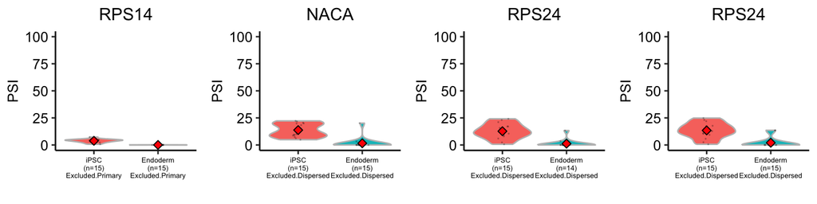

```r
# Example 1
tran_id <- "chr5:150449703:150449739|150449492:150449696:-@chr5:150447585:150447735"

marvel.demo <- PlotValues(MarvelObject=marvel.demo,
                          cell.group.list=cell.group.list,
                          feature=tran_id,
                          xlabels.size=5,
                          level="splicing",
                          min.cells=5
                          )

plot.1 <- marvel.demo$adhocPlot$PSI

# Example 2
tran_id <- "chr12:56725340:56724962|56725263:-@chr12:56724452:56724523"

marvel.demo <- PlotValues(MarvelObject=marvel.demo,
                          cell.group.list=cell.group.list,
                          feature=tran_id,
                          xlabels.size=5,
                          level="splicing",
                          min.cells=5
                          )

plot.2 <- marvel.demo$adhocPlot$PSI

# Example 3
tran_id <- "chr10:78037194:78037304:+@chr10:78037439:78037441:+@chr10:78040204:78040225"

marvel.demo <- PlotValues(MarvelObject=marvel.demo,
                          cell.group.list=cell.group.list,
                          feature=tran_id,
                          xlabels.size=5,
                          level="splicing",
                          min.cells=5
                          )

plot.3 <- marvel.demo$adhocPlot$PSI

# Example 4
tran_id <- "chr10:78037194:78037304:+@chr10:78037439|78040204:78040225"

marvel.demo <- PlotValues(MarvelObject=marvel.demo,
                          cell.group.list=cell.group.list,
                          feature=tran_id,
                          xlabels.size=5,
                          level="splicing",
                          min.cells=5
                          )

plot.4 <- marvel.demo$adhocPlot$PSI

# Arrange and view plots
# Read plots from right to left for each row
grid.arrange(plot.1, plot.2,
             plot.3, plot.4,
             nrow=1)
```

# Gene-splicing dynamics

MARVEL’s integrated differential gene and splicing analysis enables us to investigate how gene expression changes relative to splicing changes when iPSCs differentiate into endoderm cells. The gene-splicing dynamics may be classified into four categories, namely coordinated, opposing, isoform-switching, and complex.

- **Coordinated** gene-splicing relationship refers to the change in mean gene expression is in the same direction with the corresponding splicing event(s).
- **Opposing** gene-splicing relationship refers to the change in mean gene expression is in the opposite direction to the corresponding splicing event(s).
- **Isoform-switching** refers to genes that are differentially spliced without being differentially expressed.
- **Complex** gene-splicing relationship refers to genes with both coordinated and opposing relationships with the corresponding splicing events.

Here, we will explore the gene-splicing dynamics of genes that are differentially spliced between iPSCs and endoderm cells. Representative examples of each dynamic will also be shown. This section also utilises the ad hoc plotting function `PlotValues` for plotting selected splicing events and genes.  
Please note that the function `CompareValues` with the `level` option set to `gene.spliced` needs to be executed prior to proceeding with gene-splicing dynamics analysis below. Kindly refer to `Differential (spliced) gene analysis` section of this tutorial.

## Assign dynamics

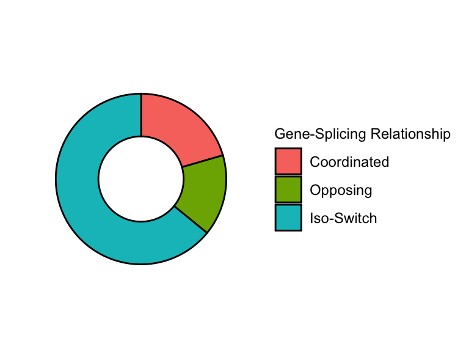

```r
marvel.demo <- IsoSwitch(MarvelObject=marvel.demo,
                         method=c("ad", "dts"),
                         psi.pval=c(0.10, 0.10),
                         psi.delta=0,
                         gene.pval=0.10,
                         gene.log2fc=0.5
                         )

marvel.demo$DE$Cor$Plot
```

```r
head(marvel.demo$DE$Cor$Table)
```

```
##               gene_id gene_short_name      gene_type         cor
## 3  ENSG00000128739.22           SNRPN protein_coding Coordinated
## 7  ENSG00000196531.10            NACA protein_coding  Iso-Switch
## 17  ENSG00000239672.7            NME1 protein_coding Coordinated
## 19 ENSG00000109475.16           RPL34 protein_coding  Iso-Switch
## 20 ENSG00000156482.11           RPL30 protein_coding  Iso-Switch
## 21 ENSG00000111237.18           VPS29 protein_coding  Iso-Switch
```

```r
marvel.demo$DE$Cor$Plot.Stats
```

```
##           cor freq      pct
## 1 Coordinated    8 20.51282
## 2    Opposing    6 15.38462
## 3  Iso-Switch   25 64.10256
```

## Coordinated

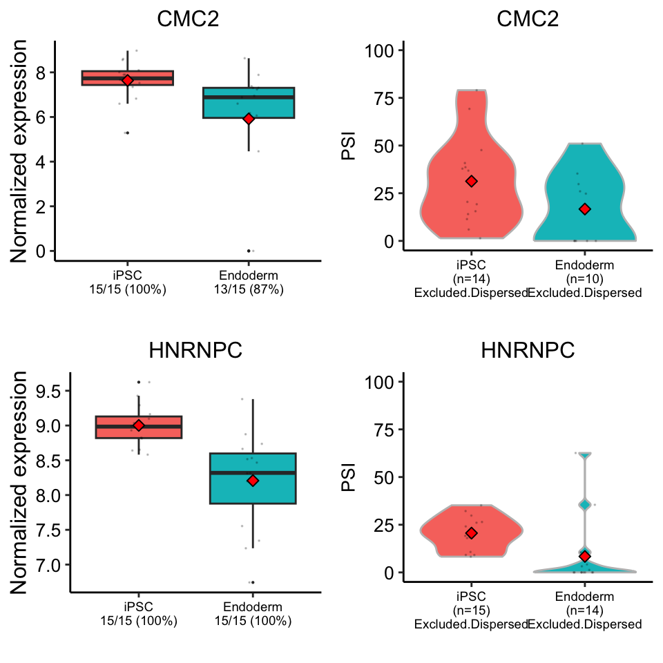

```r
# Define cell groups
    # Retrieve sample metadata
    df.pheno <- marvel.demo$SplicePheno

    # Group 1
    sample.ids.1 <- df.pheno[which(df.pheno$cell.type=="iPSC"), "sample.id"]

    # Group 2
    sample.ids.2 <- df.pheno[which(df.pheno$cell.type=="Endoderm"), "sample.id"]

    # Merge
    cell.group.list <- list("iPSC"=sample.ids.1,
                            "Endoderm"=sample.ids.2
                            )

# Example 1
  # Gene
  df.feature <- marvel.demo$GeneFeature
  gene_id <- df.feature[which(df.feature$gene_short_name=="CMC2"), "gene_id"]

  marvel.demo <- PlotValues(MarvelObject=marvel.demo,
                            cell.group.list=cell.group.list,
                            feature=gene_id,
                            maintitle="gene_short_name",
                            xlabels.size=7,
                            level="gene"
                            )

  plot.1_gene <- marvel.demo$adhocPlot$Exp

  # Splicing
  tran_id <- "chr16:80981806:80981877:-@chr16:80980808:80980879|80976003:80976179"

  marvel.demo <- PlotValues(MarvelObject=marvel.demo,
                            cell.group.list=cell.group.list,
                            feature=tran_id,
                            xlabels.size=7,
                            level="splicing",
                            min.cells=5
                            )

  plot.1_splicing <- marvel.demo$adhocPlot$PSI

# Example 2
  # Gene
  df.feature <- marvel.demo$GeneFeature
  gene_id <- df.feature[which(df.feature$gene_short_name=="HNRNPC"), "gene_id"]

  marvel.demo <- PlotValues(MarvelObject=marvel.demo,
                            cell.group.list=cell.group.list,
                            feature=gene_id,
                            maintitle="gene_short_name",
                            xlabels.size=7,
                            level="gene"
                            )

  plot.2_gene <- marvel.demo$adhocPlot$Exp

  # Splicing
  tran_id <- "chr14:21231072:21230958|21230997:-@chr14:21230319:21230366"

  marvel.demo <- PlotValues(MarvelObject=marvel.demo,
                            cell.group.list=cell.group.list,
                            feature=tran_id,
                            xlabels.size=7,
                            level="splicing",
                            min.cells=5
                           )

  plot.2_splicing <- marvel.demo$adhocPlot$PSI

# Arrange and view plots
# Read plots from right to left for each row
grid.arrange(plot.1_gene, plot.1_splicing,
             plot.2_gene, plot.2_splicing,
             nrow=2)
```

- For *CMC2* and *HNRNPC*, both gene expression and splicing rate for the splicing event shown here are decreased in endoderm cells relative to iPSCs.

## Opposing

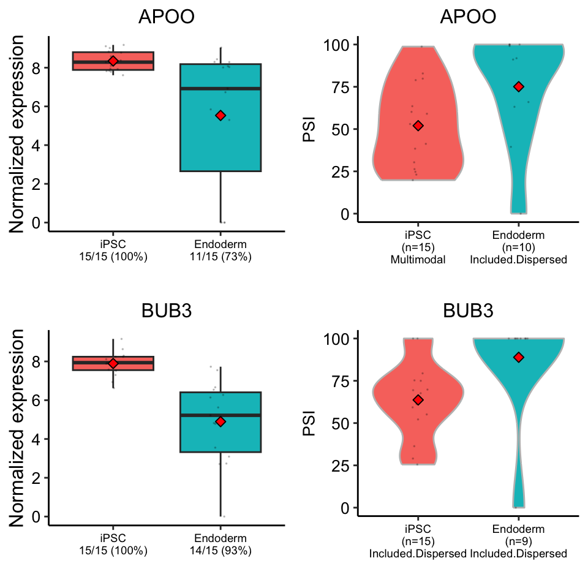

```r
# Example 1
  # Gene
  df.feature <- marvel.demo$GeneFeature
  gene_id <- df.feature[which(df.feature$gene_short_name=="APOO"), "gene_id"]

  marvel.demo <- PlotValues(MarvelObject=marvel.demo,
                            cell.group.list=cell.group.list,
                            feature=gene_id,
                            maintitle="gene_short_name",
                            xlabels.size=7,
                            level="gene"
                            )

  plot.1_gene <- marvel.demo$adhocPlot$Exp

  # Splicing
  tran_id <- "chrX:23840313:23840377:-@chrX:23833353:23833612|23833367:23833510"

  marvel.demo <- PlotValues(MarvelObject=marvel.demo,
                            cell.group.list=cell.group.list,
                            feature=tran_id,
                            xlabels.size=7,
                            level="splicing",
                            min.cells=5
                            )

  plot.1_splicing <- marvel.demo$adhocPlot$PSI

# Example 2
  # Gene
  df.feature <- marvel.demo$GeneFeature
  gene_id <- df.feature[which(df.feature$gene_short_name=="BUB3"), "gene_id"]

  marvel.demo <- PlotValues(MarvelObject=marvel.demo,
                            cell.group.list=cell.group.list,
                            feature=gene_id,
                            maintitle="gene_short_name",
                            xlabels.size=7,
                            level="gene"
                            )

  plot.2_gene <- marvel.demo$adhocPlot$Exp

  # Splicing
  tran_id <- "chr10:123162612:123162828:+@chr10:123163820:123170467|123165047:123165365"

  marvel.demo <- PlotValues(MarvelObject=marvel.demo,
                            cell.group.list=cell.group.list,
                            feature=tran_id,
                            xlabels.size=7,
                            level="splicing",
                            min.cells=5
                            )

  plot.2_splicing <- marvel.demo$adhocPlot$PSI

# Arrange and view plots
# Read plots from right to left for each row
grid.arrange(plot.1_gene, plot.1_splicing,
             plot.2_gene, plot.2_splicing,
             nrow=2)
```

- For both *APOO* and *BUB3*, the gene expression is decreased in endoderm cells relative to iPSCs.
- However, the mean splicing rates of the splicing events shown here are increased in endoderm cells relative to iPSCs.

## Iso-switch

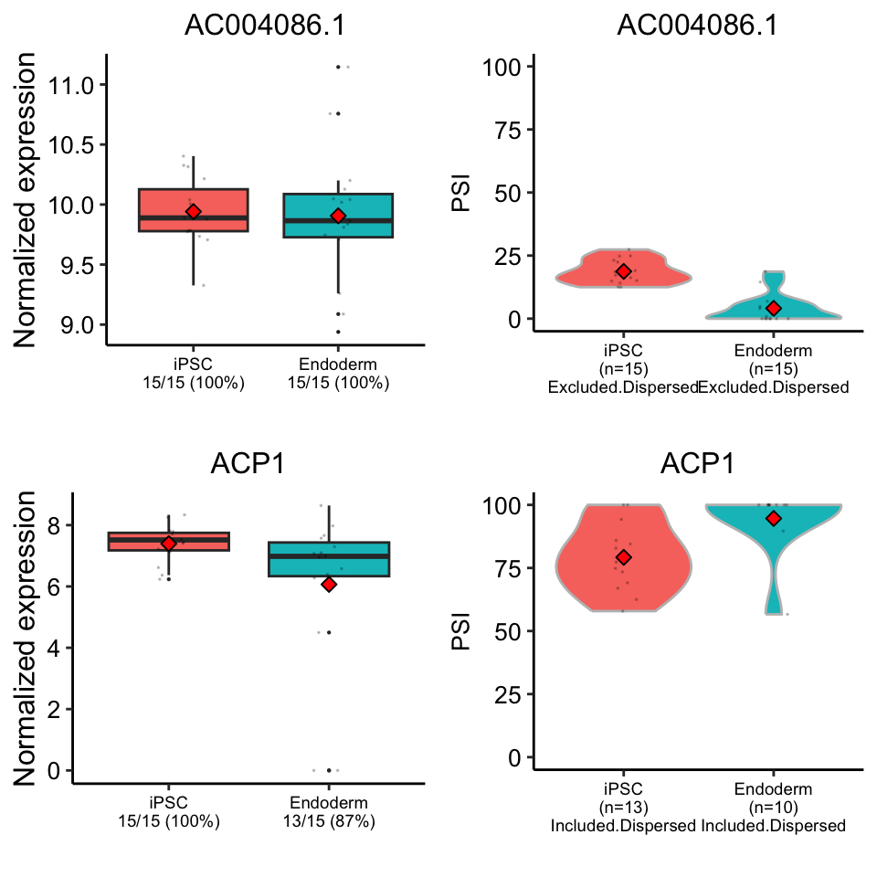

```r
# Example 1
  # Gene
  df.feature <- marvel.demo$GeneFeature
  gene_id <- df.feature[which(df.feature$gene_short_name=="AC004086.1"), "gene_id"]

  marvel.demo <- PlotValues(MarvelObject=marvel.demo,
                            cell.group.list=cell.group.list,
                            feature=gene_id,
                            maintitle="gene_short_name",
                            xlabels.size=7,
                            level="gene"
                            )

  plot.1_gene <- marvel.demo$adhocPlot$Exp

  # Splicing
  tran_id <- "chr12:112409641:112409411|112409587:-@chr12:112408420:112408656"

  marvel.demo <- PlotValues(MarvelObject=marvel.demo,
                            cell.group.list=cell.group.list,
                            feature=tran_id,
                            xlabels.size=7,
                            level="splicing",
                            min.cells=5
                            )

  plot.1_splicing <- marvel.demo$adhocPlot$PSI

# Example 2
  # Gene
  df.feature <- marvel.demo$GeneFeature
  gene_id <- df.feature[which(df.feature$gene_short_name=="ACP1"), "gene_id"]

  marvel.demo <- PlotValues(MarvelObject=marvel.demo,
                            cell.group.list=cell.group.list,
                            feature=gene_id,
                            maintitle="gene_short_name",
                            xlabels.size=7,
                            level="gene"
                            )

  plot.2_gene <- marvel.demo$adhocPlot$Exp

  # Splicing
  tran_id <- "chr2:271866:271939:+@chr2:272037:272150:+@chr2:272192:272305:+@chr2:275140:275201"

  marvel.demo <- PlotValues(MarvelObject=marvel.demo,
                            cell.group.list=cell.group.list,
                            feature=tran_id,
                            xlabels.size=7,
                            level="splicing",
                            min.cells=5
                            )

  plot.2_splicing <- marvel.demo$adhocPlot$PSI

# Arrange and view plots
# Read plots from right to left for each row
grid.arrange(plot.1_gene, plot.1_splicing,
             plot.2_gene, plot.2_splicing,
             nrow=2)
```

- For both *AC004086.1* and *ACP1*, the differences in gene expression between iPSCs and endoderm cells are not statistically significant.
- However, the corresponding splicing patterns of the splicing events shown here are significantly different between iPSCs and endoderm cells.

# Gene ontology analysis

Gene ontology analysis or pathway enrichment analysis categorises the differentially spliced genes between iPSCs and endoderm cell into biological pathways. This may identify sets of genes with similar function or belong to similar biological pathways that are concurrently spliced.  
Gene ontology analysis represents one of the two functional annotation features of MARVEL. The other functional annotation feature is nonsense-mediated (NMD) analysis.

```r
marvel.demo <- BioPathways(MarvelObject=marvel.demo,
                           method=c("ad", "dts"),
                           pval=0.10,
                           species="human"
                           )

head(marvel.demo$DE$BioPathways$Table)
```

- `method` option. Merge results from `ad` and `dts` statistical test.
- `pval` option. The adjusted p-value, below which, the splicing event is considered to be differentially spliced.
- `species` option. MARVEL also supports GO analysis of `"mouse"`.
- `custom.genes` option. In lieu of specifying genes with the `method` and `pval` options, users may specify any custom set of genes using this option.

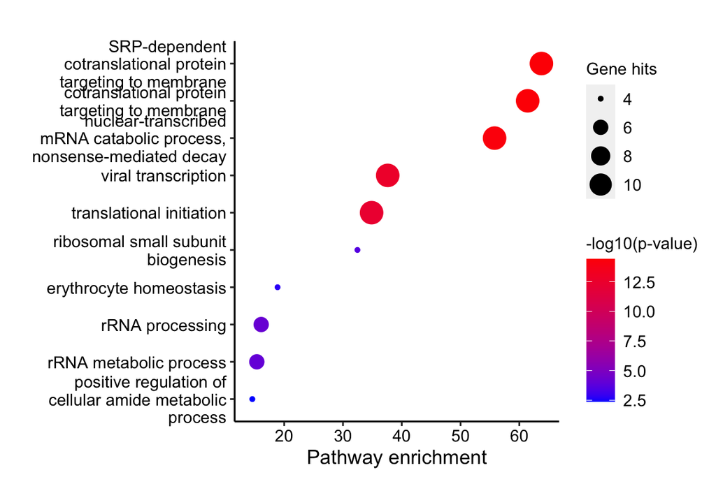

```r
# Plot top pathways
df <- marvel.demo$DE$BioPathways$Table
go.terms <- df$Description[c(1:10)]

marvel.demo <- BioPathways.Plot(MarvelObject=marvel.demo,
                                go.terms=go.terms,
                                y.label.size=10
                                )

marvel.demo$DE$BioPathways$Plot
```

- The top biological pathways enriched among differentially spliced genes are related to transcription, translation, and metabolism.
- Users can plot the enrichment results of any biological pathways of interest arising from `BioPathways` function. Simply specify the custom set of pathways using the `go.terms` option of the `BioPathways.Plot` function.

# Companion tool: VALERIE